# An Introduction to LSTM Modelling for Stock Price Prediction and Analysis

In this model, I will be implementing LSTM as Time Series Analysis in order to backtest and predict Bitcoin between January 1st, 2015 to December 28th, 2020, which is the most current pricing data that I am able to retreive.

LSTM stands for Long Short-Term Memory, and it is a kind of Recurrent Neural Network (referred to as RNN from now on) which allow information to persist given some sequential data.

To start, RNN's are different from standard feedforward neural networks in that RNN's have a feedback loop in which data from the output can be fed back into the input before it continues. This would allow for a derived, dynamic "memory" in that their 'state' is continuously changing until it hits an equilibrium point, at which it remains there until the input changes and the RNN needs to find a new equlibrium point. Therfore, RNN's are particularly well suited to classify, process, and make predictions on time-series data given that they can connect previous information to the present task.

However, their downside is that the longer the dependency (for the past), the larger the possible gap for missing context becomes, therefore also making RNN's flawed. To expand on this, during back propagation, RNN's suffer from the vanishing gradient problem. Gradients are used to update a NN's weights, and the vanishing gradient problem is when the gradient shrinks as it back propagates through time, and if the gradient value becomes extremely small, it doesn't contribute to much learning. Therefore, given a long sequence of data, RNN's have a hard time carrying information from earlier time steps to later ones. This is where LSTM models come in.

LSTM models, on the other hand, are designed to avoid the long-term dependency problem. Given the chain-like structure in a standard RNN, an LSTM model adds to it by allowing the ability to remove or add information to the state, which are regulated by gates, thus minimizing the error flow between cells in the state.

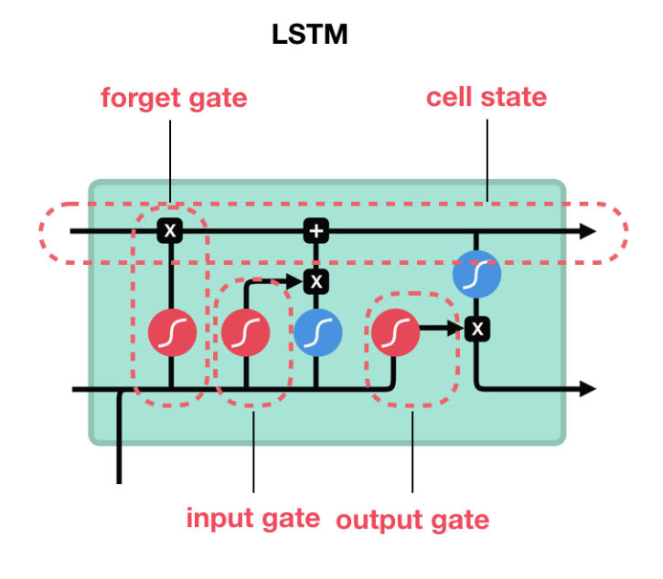

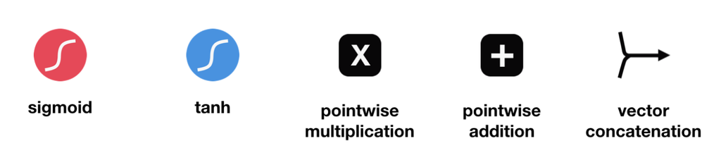

As a simple elaboration, this above is a single cell in a "highway", where this "highway" is the state. This highway can be considered as the "memory" of the entire network as well. As the cell state (the "car") goes along its journey through cells, information gets added or removed to the cell state through gates, where these gates decide which information is allowed or not allowed on the cell state.

In typical RNN's there is only a tanh activation. The tanh activation helps control the values as they pass through the network by squishing those values between -1 and 1 so they are manageable at the end of the network.

In LSTM, there is also Sigmoid, which instead of squishing values between -1 and 1, it squished values between 0 and 1. This gate helps determine if the information is the same as before (which keeps it), or if it should update data or forget the data (closer to 0, more likely to delete the data through multiplication, and vice versa).

LSTM also has a forget gate, which decides if the information should be thrown away or kept. After the information passes through the Sigmoid, if the values are closer to 0, it would be more likely to be forgotten through the forget gate, and if they are closer to 1, they would be more likely to be kept.

The input gate is to help update the cell state, where you pass the previous (hidden) state and the current input into a sigmoid function. They are also passed through a tanh function to help regulate the output, and then the tanh output gets multiplied with the sigmoid output. The sigmoid output will decide which information is important to keep from the tanh output.

Now the cell state becomes important (top horizontal line), where the cell state gets multiplied by the forget vector, which allows for the possibility of dropping values in the cell state if the value is closer to 0. Then that output is taken and a pointwise addition is done which updates the cell state to new values that the neural network finds relevant. That gives us the new cell state.

Finally, there is the output gate. The output gate decides what the next hidden value should be. The hidden state contains information on previous inputs as well as being for predictions. First, we pass the previous hidden state and the current input into a sigmoid function. Then, on the top, the current "car" or the current state is passed through the tanh function. These two values are multiplied to detecide what information the hidden state should carry, and the output is the hidden state.

Given this explanation of LSTM, it is now implemented to use for Bitcoin price prediction from January 1st, 2015 to December 28th, 2020. Cryptocurrency is used as it trades 24/7 for 365 days so we can get a more accurate estimate and a more likely prediction. First, we install packages that might've not been installed previously (this was done and then the code was deleted as the results took up too much space). We will be using Keras, Plotly, Pandas, NumPy, Matplotlib, TensorFlow, and some additional Python code.

After installing the necessary packages, I will print out some initial data after importing the .csv file (obtained from Yahoo Finance), as well as the plot of the data that I am using. The prices that I will be using are the daily closing prices at 11:59pm. There are 2190 days in total in the .csv file.

```python
import pandas as pd
import numpy as np

import matplotlib.pyplot as plt
%matplotlib inline

from matplotlib.pylab import rcParams
rcParams['figure.figsize'] = 20,20

from sklearn.preprocessing import MinMaxScaler
scaler = MinMaxScaler(feature_range=(0, 1))

df = pd.read_csv('BTC-USD (2015).csv')

df.head()
```

|  | Date | Open | High | Low | Close | Adj Close | Volume |
| --- | --- | --- | --- | --- | --- | --- | --- |
| 0 | 2015-01-01 | 320.434998 | 320.434998 | 314.002991 | 314.248993 | 314.248993 | 8036550 |
| 1 | 2015-01-02 | 314.079010 | 315.838989 | 313.565002 | 315.032013 | 315.032013 | 7860650 |
| 2 | 2015-01-03 | 314.846008 | 315.149994 | 281.082001 | 281.082001 | 281.082001 | 33054400 |
| 3 | 2015-01-04 | 281.145996 | 287.230011 | 257.612000 | 264.195007 | 264.195007 | 55629100 |
| 4 | 2015-01-05 | 265.084015 | 278.341003 | 265.084015 | 274.473999 | 274.473999 | 43962800 |

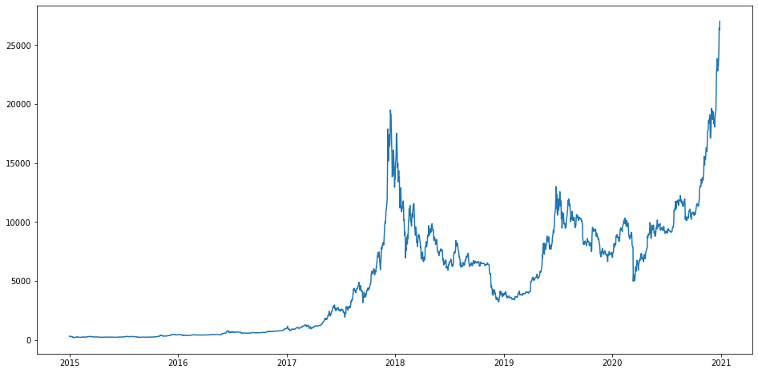

```python
df['Date'] = pd.to_datetime(df.Date, format='%Y-%m-%d')
df.index = df['Date']

plt.figure(figsize=(16,8))
plt.plot(df['Close'], label='Close Price history')
```

After visualizing the initial data, I will run this through Keras and TensorFlow, training the data before November 27th, 2018 and backtesting all the data that comes after that date. I will set 15 days as the lookback period, as well as 50 epochs, which means that the network will run through the entire data 50 times, updating state each time for a more accurate estimation.

```python
import keras
import tensorflow as tf
from keras.preprocessing.sequence import TimeseriesGenerator

#creating a new dataframe to organize the data
data = df.sort_index(ascending=True, axis=0)
new_data = pd.DataFrame(index=range(0,len(df)),columns=['Date', 'Close'])
for i in range(0,len(data)):
    new_data['Date'][i] = data['Date'][i]
    new_data['Close'][i] = data['Close'][i]

#setting index
new_data.index = new_data.Date

close_data = new_data['Close'].values
close_data = close_data.reshape((-1,1))

close_train = close_data[:1428]
close_test = close_data[1428:]

date_train = df['Date'][:1428]
date_test = df['Date'][1428:]

close_train = close_train.astype(np.float32)
close_test = close_test.astype(np.float32)

look_back = 15

train_generator = TimeseriesGenerator(close_train, close_train, length=look_back, batch_size=20)
test_generator = TimeseriesGenerator(close_test, close_test, length=look_back, batch_size=1)

from keras.models import Sequential
from keras.layers import LSTM, Dense

model = Sequential()
model.add(
    LSTM(10,
        activation='relu',
        input_shape=(look_back,1))
)
model.add(Dense(1))
model.compile(optimizer='adam', loss='mse')

num_epochs = 50
model.fit_generator(train_generator, epochs=num_epochs, verbose=0)


prediction = model.predict_generator(test_generator)

close_train = close_train.reshape((-1))
close_test = close_test.reshape((-1))
prediction = prediction.reshape((-1))

import plotly.graph_objs as go
import plotly.offline as pyo

pyo.init_notebook_mode()

trainingDataLine = go.Scatter(
    x = date_train,
    y = close_train,
    mode = 'lines',
    name = 'Training Data'
)
predictionLine = go.Scatter(
    x = date_test,
    y = prediction,
    mode = 'lines',
    name = 'Prediction'
)
actualDataLine = go.Scatter(
    x = date_test,
    y = close_test,
    mode='lines',
    name = 'Actual Data'
)
layout = go.Layout(
    title = "Cryptocurrency: Bitcoin (BTC)",
    xaxis = {'title' : "Date"},
    yaxis = {'title' : "Closing Price"}
)
fig = go.Figure(data=[trainingDataLine, predictionLine, actualDataLine], layout=layout)
fig.show()
```

[interactive chart not shown]

Now I will attempt to predict the data for 45 days in the future.

```python
close_data = close_data.reshape((-1))
close_data = close_data.astype(np.float32)

def predict(num_prediction, model):
    prediction_list = close_data[-look_back:]

    for _ in range(num_prediction):
        x = prediction_list[-look_back:]
        x = x.reshape((1, look_back, 1))
        out = model.predict(x)[0][0]
        prediction_list = np.append(prediction_list, out)
    prediction_list = prediction_list[look_back-1:]

    return prediction_list

def predict_dates(num_prediction):
    last_date = df['Date'].values[-1]
    prediction_dates = pd.date_range(last_date, periods=num_prediction+1).tolist()
    return prediction_dates

num_prediction = 45
forecast = predict(num_prediction, model)
forecast_dates = predict_dates(num_prediction)


trainingDataLine = go.Scatter(
    x = date_train,
    y = close_train,
    mode = 'lines',
    name = 'Training Data'
)
predictionLine = go.Scatter(
    x = forecast_dates,
    y = forecast,
    mode = 'lines',
    name = 'Forecast'
)
actualDataLine = go.Scatter(
    x = date_test,
    y = close_test,
    mode='lines',
    name = 'Actual Data'
)
layout = go.Layout(
    title = "Cryptocurrency: Bitcoin (BTC)",
    xaxis = {'title' : "Date"},
    yaxis = {'title' : "Closing Price"}
)
fig = go.Figure(data=[trainingDataLine, predictionLine, actualDataLine], layout=layout)
fig.show()
```

[interactive chart not shown]

As a brief conclusion, future predictions aren't accurate because it's based off of 15 previous days and given that as we go further and further on the previous 15 days, the predictions become less and less accurate.

Furthermore, the stock market does not necessarily predict the stock market.

This shows that LSTM are not as predictive as we thought, but it is very helpful as a brief introduction into LSTM and stock price prediction as a method of thought.

Sources:

- https://towardsdatascience.com/illustrated-guide-to-lstms-and-gru-s-a-step-by-step-explanation-44e9eb85bf21
- https://colah.github.io/posts/2015-08-Understanding-LSTMs/
- https://en.wikipedia.org/wiki/Long_short-term_memory
- https://www.analyticsvidhya.com/blog/2018/10/predicting-stock-price-machine-learningnd-deep-learning-techniques-python/